# HumanActivityRecognitionProject

### 2. Random Forest

Confusion Matrix and Statistics

```
      Reference
```

Prediction A B C D E A 1395 8 0 0 0 B 0 941 7 0 1 C 0 0 847 18 4 D 0 0 1 786 1 E 0 0 0 0 895

Overall Statistics

```
           Accuracy : 0.9918
             95% CI : (0.9889, 0.9942)
No Information Rate : 0.2845
P-Value [Acc > NIR] : < 2.2e-16

              Kappa : 0.9897
```

Mcnemar’s Test P-Value : NA

Statistics by Class:

```
                 Class: A Class: B Class: C Class: D Class: E
```

Sensitivity 1.0000 0.9916 0.9906 0.9776 0.9933 Specificity 0.9977 0.9980 0.9946 0.9995 1.0000 Pos Pred Value 0.9943 0.9916 0.9747 0.9975 1.0000 Neg Pred Value 1.0000 0.9980 0.9980 0.9956 0.9985 Prevalence 0.2845 0.1935 0.1743 0.1639 0.1837 Detection Rate 0.2845 0.1919 0.1727 0.1603 0.1825 Detection Prevalence 0.2861 0.1935 0.1772 0.1607 0.1825 Balanced Accuracy 0.9989 0.9948 0.9926 0.9886 0.9967

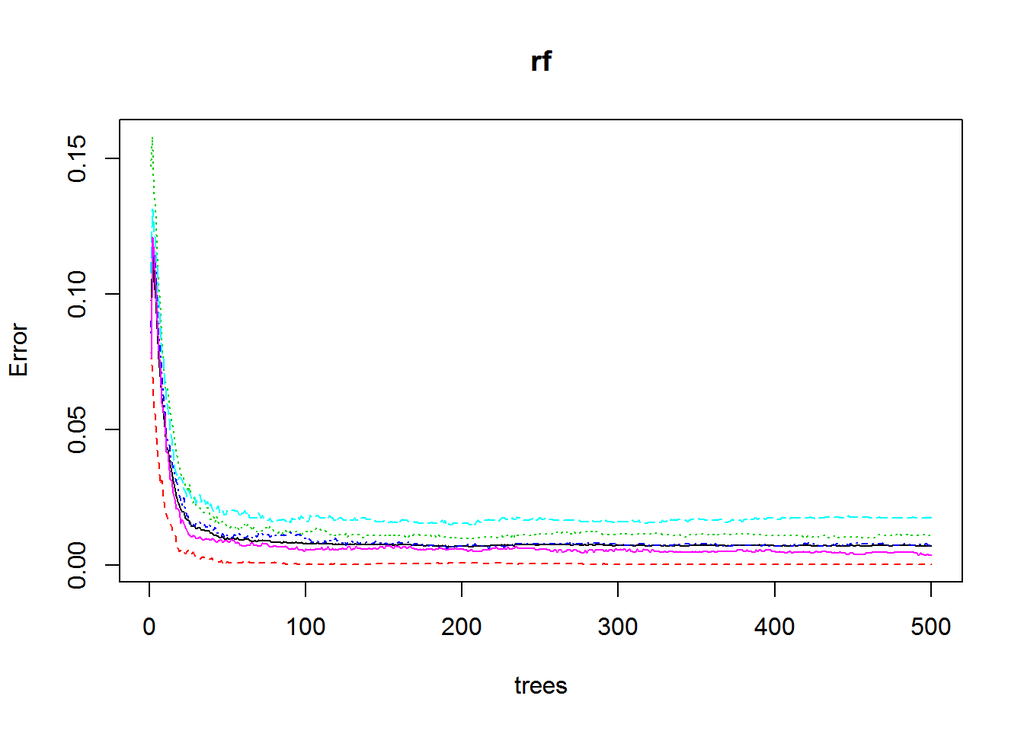

|  | Overall |
| --- | --- |
| user_name | 160.8996 |
| pitch_belt | 770.1863 |
| total_accel_belt | 335.7753 |
| gyros_belt_x | 152.1687 |
| gyros_belt_y | 174.2680 |
| accel_belt_z | 565.3539 |
| magnet_belt_x | 327.4067 |
| magnet_belt_z | 577.2187 |
| roll_arm | 383.3367 |
| pitch_arm | 219.4631 |

[output cut: 24 more lines]

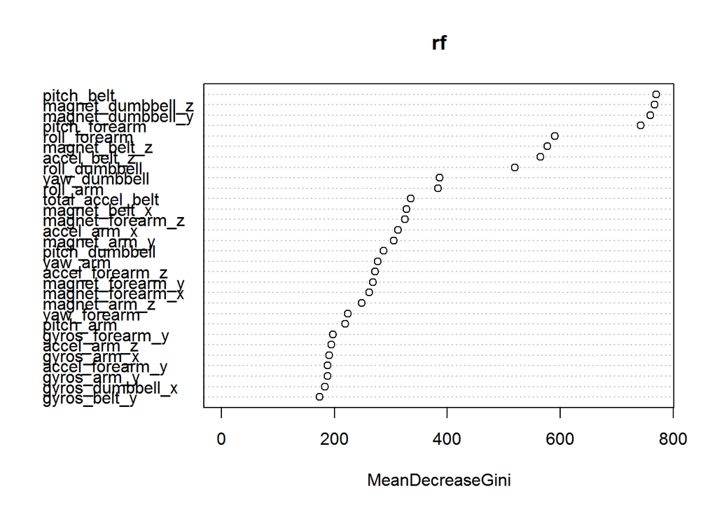

### 3. Gradient Boosting

```
  Accuracy          Kappa  AccuracyLower  AccuracyUpper   AccuracyNull
```

9.445351e-01 9.298198e-01 9.377577e-01 9.507769e-01 2.844617e-01 AccuracyPValue McnemarPValue 0.000000e+00 1.616028e-12

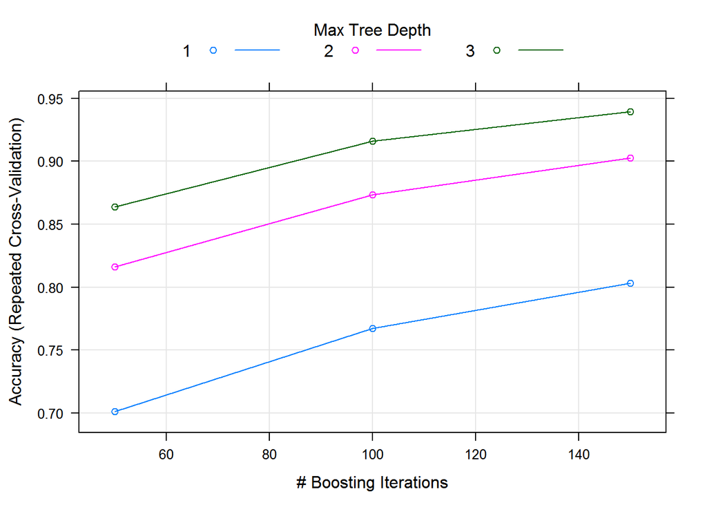

gbm variable importance

only 20 most important variables shown (out of 38)

```
              Overall
```

pitch_forearm 1808.4 accel_belt_z 1544.7 magnet_belt_z 1339.6 magnet_dumbbell_z 1135.8 magnet_dumbbell_y 1135.4 roll_dumbbell 750.0 roll_forearm 737.3 pitch_belt 635.3 magnet_forearm_z 269.8 magnet_arm_z 266.7 magnet_belt_x 266.4 magnet_forearm_x 249.1 yaw_arm 249.0 magnet_arm_y 246.1 gyros_belt_x 181.6 gyros_belt_y 171.1 roll_arm 163.2 pitch_dumbbell 158.6 gyros_arm_y 139.4 accel_forearm_z 124.7

### 4. Model based Prediction

Linear Discriminant Analysis

14718 samples 34 predictor 5 classes: ‘A’, ‘B’, ‘C’, ‘D’, ‘E’

Pre-processing: centered (38), scaled (38) Resampling: Bootstrapped (25 reps) Summary of sample sizes: 14718, 14718, 14718, 14718, 14718, 14718, … Resampling results:

Accuracy Kappa  
0.6511872 0.5588897

```
  Accuracy          Kappa  AccuracyLower  AccuracyUpper   AccuracyNull
```

6.606852e-01 5.705500e-01 6.472389e-01 6.739399e-01 2.844617e-01 AccuracyPValue McnemarPValue 0.000000e+00 1.198465e-42 Naive Bayes

14718 samples 34 predictor 5 classes: ‘A’, ‘B’, ‘C’, ‘D’, ‘E’

Pre-processing: centered (38), scaled (38) Resampling: Bootstrapped (25 reps) Summary of sample sizes: 14718, 14718, 14718, 14718, 14718, 14718, … Resampling results across tuning parameters:

usekernel Accuracy Kappa  
FALSE 0.4901071 0.3654856 TRUE 0.7167742 0.6401331

Tuning parameter ‘fL’ was held constant at a value of 0 Tuning parameter ‘adjust’ was held constant at a value of 1 Accuracy was used to select the optimal model using the largest value. The final values used for the model were fL = 0, usekernel = TRUE and adjust = 1. Accuracy Kappa AccuracyLower AccuracyUpper AccuracyNull 7.277732e-01 6.517375e-01 7.150805e-01 7.401943e-01 2.844617e-01 AccuracyPValue McnemarPValue 0.000000e+00 4.499993e-76